# HRDX Vignette

John Pluta

7/2/2019

## Sample Data

```r
head(sub01.segments)
```

```
##   chromosome start.pos   end.pos        Bf N.BAF     sd.BAF depth.ratio
## 1       chr1     14653  11964178 0.1564393   161 0.11052143   0.6882506
## 2       chr1  11998745  13371846 0.2787198   191 0.13869472   0.7155567
## 3       chr1  13371892  32768552 0.2542351   491 0.13316944   0.7255337
## 4       chr1  32770025  42450082 0.3052787   140 0.11683497   1.4090696
## 5       chr1  42500318  94102935 0.1590794   557 0.09002886   1.1685900
## 6       chr1  94103266 121382640 0.3645728   378 0.11065113   1.2104302
##   N.ratio  sd.ratio CNt A B       LPP
## 1   26382 2.0346529   3 3 0 -6.876882
## 2   19520 0.3110932   2 2 0 -6.797654
## 3   67743 0.7398484   2 2 0 -6.822322
## 4   45495 1.0491698   7 5 2 -6.812392
## 5  119937 2.0359182   5 5 0 -6.782166
## 6   86742 0.6613949   5 3 2 -6.763870
```

```r
print(sub01.ploidy)
```

```
##   cellularity ploidy.estimate ploidy.mean.cn
## 1        0.50             3.6       3.576179
## 2        0.52             3.8       3.576179
## 3        0.53             4.3       3.576179
```

## HRD Scoring

**Preprocessing**

The package needs to define the centromere and telomere positions for each chromosome; the overall chromosome size; the length of each segment; the length of the gaps between segments; the p, q, and cross arms; and allelic imbalance. This is all achieved using the function “preprocessSeq”. All positions are stored in the reference data within the package; both grch37 and grch38 are supported. The other stuff is calculated from the data.

```r
seq.dat <- sub01.segments[ sub01.segments$chromosome == "chr1",]
preprocessSeq( seq.dat )
```

```
##    chromosome start.pos   end.pos        Bf N.BAF     sd.BAF depth.ratio
## 1        chr1     14653  11964178 0.1564393   161 0.11052143   0.6882506
## 3        chr1  11998745  32768552 0.2542351   491 0.13316944   0.7255337
## 4        chr1  32770025  42450082 0.3052787   140 0.11683497   1.4090696
## 5        chr1  42500318  94102935 0.1590794   557 0.09002886   1.1685900
## 6        chr1  94103266 121382640 0.3645728   378 0.11065113   1.2104302
## 8        chr1 143461198 152221068 0.3551582    49 0.12654292   0.8207542
## 9        chr1 152223103 227434310 0.4076886  1102 0.09709579   0.9676428
## 10       chr1 227493520 228308313 0.3502327    34 0.13758169   0.5148259
## 11       chr1 228317503 248650825 0.3919097   370 0.10944744   1.0248713
##    N.ratio  sd.ratio CNt A B       LPP    frac.chr brk.len        s
## 1    26382 2.0346529   3 3 0 -6.876882 0.047941806       0 11949525
## 3    67743 0.7398484   2 2 0 -6.822322 0.077819906      46 20769807
## 4    45495 1.0491698   7 5 2 -6.812392 0.038836641    1473  9680057
## 5   119937 2.0359182   5 5 0 -6.782166 0.207031047   50236 51602617
## 6    86742 0.6613949   5 3 2 -6.763870 0.109445561     331 27279374
## 8    19209 0.4661342   3 2 1 -6.759331 0.006916990  152904  8759870
## 9   238987 0.6031059   4 2 2 -7.262171 0.301749326    2035 75211207
## 10    2238 0.6886043   1 1 0 -6.759492 0.003268971   59210   814793
## 11   46427 0.5949593   4 2 2 -6.737557 0.081577819    9190 20333322
##     chr.size    AI end.arm start.arm cross.arm post.telomere pre.telomere
## 1  249250621 FALSE       q         q     FALSE         FALSE        FALSE
## 3  249250621 FALSE       q         q     FALSE         FALSE        FALSE
## 4  249250621  TRUE       q         q     FALSE         FALSE        FALSE
## 5  249250621 FALSE       q         q     FALSE         FALSE        FALSE
## 6  249250621  TRUE       q         q     FALSE         FALSE        FALSE
## 8  249250621  TRUE       p         p     FALSE         FALSE        FALSE
## 9  249250621 FALSE       p         p     FALSE         FALSE        FALSE
## 10 249250621 FALSE       p         p     FALSE         FALSE        FALSE
## 11 249250621 FALSE       p         p     FALSE         FALSE        FALSE
```

**Quality Control**

Part of preprocessing is identifying errors in defining segments. For example, on chromosome 14:

```r
cols <- c(1,2,3,10,11,12)
seq.dat <- sub01.segments[ sub01.segments$chromosome == "chr14", ]
seq.dat[,cols]
```

```
##     chromosome start.pos   end.pos CNt A B
## 100      chr14  16028300  16049338   1 1 0
## 101      chr14  18341590  19485620   4 3 1
## 102      chr14  19492346 104014746   3 2 1
## 103      chr14 104015995 106874951   3 2 1
```

notice that the last two segments have a very small gap between them, with identical copynumber status. This suggests that this is really one full segment being incorrectly identified as two. The function combineSegs is called within preprocessSeq to correct these:

```r
seq.dat <- preprocessSeq( seq.dat )
seq.dat[,cols]
```

```
##     chromosome start.pos   end.pos CNt A B
## 100      chr14  16028300  16049338   1 1 0
## 101      chr14  18341590  19485620   4 3 1
## 103      chr14  19492346 106874951   3 2 1
```

After the preprocessing function runs, the last two segments are combined into one.

**Normalization**

It is recommended that you use normalized values for HRD measures. Each genomic doubling creates a copy of each HRD event. At baseline, tumors are diploid (ploidy = 2). For tetraploid tumors (ploidy = 4), the number of genomic events is doubled. To adjust for ploidy, the raw score from a diploid tumor would be divided 1; for a tetraploid tumor, divided by 2; and so on. This can be expressed mathematically as:

**HRD Measures**

Once the data has been preprocessed, you can calculate HRD measures LST, LOH, TAI, and NTAI. Each metric is retrieved with a corresponding function.

*LST*

Raw LST is the number of large state transition events. LST is normalized by ploidy.

```r
seq.dat <- preprocessHRD( sub01.segments )
getLST.raw( seq.dat )
```

```
## [1] 35
```

```r
getLST.norm( seq.dat, sub01.ploidy )
```

```
## [1] 18.42105
```

*LOH*

Raw LOH is the number of loss of heterozygosity events. LOH is normalized by ploidy.

```r
getLOH.raw( seq.dat )
```

```
## [1] 24
```

```r
getLOH.norm( seq.dat, sub01.ploidy )
```

```
## [1] 12.63158
```

*NTAI*

Raw NTAI is the number of nontelomeric allelic imbalance events. NTAI is normalized by removing main copynumber segments.

```r
CN.dat <- getCNt( seq.dat )
getNTAI.raw( seq.dat )
```

```
## [1] 22
```

```r
getNTAI.norm( seq.dat, CN.dat)
```

```
## [1] 16
```

*HRD Score*

An HRD Score is some linear combination of raw or normalized values LST, LOH, NTAI (or TAI). You can use the total or average of the three metrics. getHRD.Score is a convenient function for calculating the ‘standard’ HRD score (what we use in Maxwell et al.), which is the sum of LST, LOH, and NTAI, all normalized. It is intended to return the HRD score without having to specify all the individual arguments. Optionally, you can rescale the data to fit a range of 0 - 100. For a single subject, an HRD score can be easily be calculated from raw data in just a few steps:

```r
seq.dat <- preprocessHRD( sub01.segments )
CN.dat  <- getCNt( seq.dat )

HRD <- getHRD.Score( seq.dat, CN.dat, sub01.ploidy )
print(HRD)
```

```
## [1] 47.05263
```

## Aneuploidy

Aneuploidy processing uses different criteria than HRD. Therefore, you should run getAneuploidy on the raw data- dont run preprocessHRD.

```r
ap.chr1 <- getAneuploidy(sub01.segments, sub01.ploidy, 1)

# summary data
ap.chr1[[1]]
```

```
##   p.aneuploid q.aneuploid  chr
## 1       FALSE       FALSE chr1
```

```r
# full data
ap.chr1[[2]]
```

```
##    chromosome start.pos   end.pos        Bf N.BAF     sd.BAF depth.ratio
## 3        chr1     14653  32768552 0.2542351   491 0.13316944   0.7255337
## 6        chr1  32770025 121382640 0.3645728   378 0.11065113   1.2104302
## 8        chr1 143461198 152221068 0.3551582    49 0.12654292   0.8207542
## 9        chr1 152223103 227434310 0.4076886  1102 0.09709579   0.9676428
## 10       chr1 227493520 228308313 0.3502327    34 0.13758169   0.5148259
## 11       chr1 228317503 248650825 0.3919097   370 0.10944744   1.0248713
##    N.ratio  sd.ratio CNt A B       LPP brk.len arm    a.stat        s
## 3    67743 0.7398484   2 2 0 -6.822322      46   p   Deleted 32753899
## 6    86742 0.6613949   5 3 2 -6.763870     331   p Amplified 88612615
## 8    19209 0.4661342   3 2 1 -6.759331  152904   q   Deleted  8759870
## 9   238987 0.6031059   4 2 2 -7.262171       0   q   Neutral 75211207
## 10    2238 0.6886043   1 1 0 -6.759492       0   q   Deleted   814793
## 11   46427 0.5949593   4 2 2 -6.737557       0   q   Neutral 20333322
```

```r
ap.dat <- getAneuploidyGenome(sub01.segments, sub01.ploidy)
ap.dat[[1]]
```

```
##    p.aneuploid q.aneuploid   chr
## 1        FALSE       FALSE  chr1
## 2        FALSE       FALSE  chr2
## 3        FALSE        TRUE  chr3
## 4        FALSE       FALSE  chr4
## 5        FALSE       FALSE  chr5
## 6        FALSE       FALSE  chr6
## 7        FALSE       FALSE  chr7
## 8         TRUE       FALSE  chr8
## 9        FALSE       FALSE  chr9
## 10       FALSE        TRUE chr10
## 11       FALSE       FALSE chr11
## 12       FALSE       FALSE chr12
## 13       FALSE       FALSE chr13
## 14       FALSE        TRUE chr14
## 15       FALSE       FALSE chr15
## 16        TRUE        TRUE chr16
## 17        TRUE        TRUE chr17
## 18        TRUE       FALSE chr18
## 19        TRUE        TRUE chr19
## 20       FALSE       FALSE chr20
## 21       FALSE       FALSE chr21
## 22       FALSE       FALSE chr22
## 23       FALSE       FALSE  chrX
```

```r
getAneuploidyScore(ap.dat[[1]])
```

```
## [1] 11
```

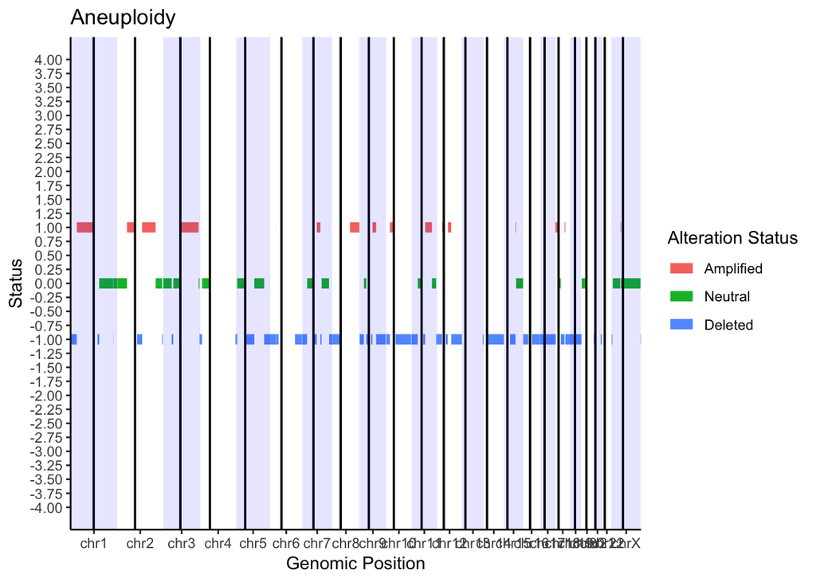

```r
plotAneuploidy(ap.dat[[2]])
```